# Análise e Modelagem Classificatória de Dados de Câncer de Mama - 2 Análise exploratória de Dados

O seguinte capítulo tem como objetivo realizar uma análise exploratória nos dados. Para isso iremos seguir o seguinte esquema:

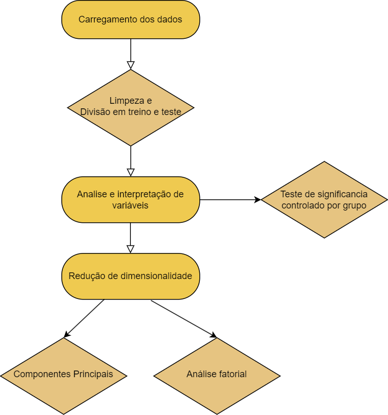

## 2.1 Carregamento dos dados

Os dados utilizados nesse trabalho foram retirados do [**Kaggle**](https://www.kaggle.com/datasets/uciml/breast-cancer-wisconsin-data?resource=download) e se tratam de valores estimados a partir de uma imagem digitalizada de um aspirado com agulha fina (PAAF) de uma massa mamária com tumor. Assim, os dados descrevem características dos núcleos celulares presentes nas imagens.

Carregamento dos dados:

```
Rows: 568
Columns: 33
$ id                      <dbl> 842302, 842517, 84300903, 84348301, 84358402, …
$ diagnosis               <fct> M, M, M, M, M, M, M, M, M, M, M, M, M, M, M, M…
$ radius_mean             <dbl> 17.990, 20.570, 19.690, 11.420, 20.290, 12.450…
$ texture_mean            <dbl> 10.38, 17.77, 21.25, 20.38, 14.34, 15.70, 19.9…
$ perimeter_mean          <dbl> 122.80, 132.90, 130.00, 77.58, 135.10, 82.57, …
$ area_mean               <dbl> 1001.0, 1326.0, 1203.0, 386.1, 1297.0, 477.1, …
$ smoothness_mean         <dbl> 0.11840, 0.08474, 0.10960, 0.14250, 0.10030, 0…
$ compactness_mean        <dbl> 0.27760, 0.07864, 0.15990, 0.28390, 0.13280, 0…
$ concavity_mean          <dbl> 0.30010, 0.08690, 0.19740, 0.24140, 0.19800, 0…
$ concave_points_mean     <dbl> 0.14710, 0.07017, 0.12790, 0.10520, 0.10430, 0…
$ symmetry_mean           <dbl> 0.2419, 0.1812, 0.2069, 0.2597, 0.1809, 0.2087…
$ fractal_dimension_mean  <dbl> 0.07871, 0.05667, 0.05999, 0.09744, 0.05883, 0…
$ radius_se               <dbl> 1.0950, 0.5435, 0.7456, 0.4956, 0.7572, 0.3345…
```

[output cut: 20 more lines]

Nota-se que o conjunto de dados possui 568 observações com 33 variaveis

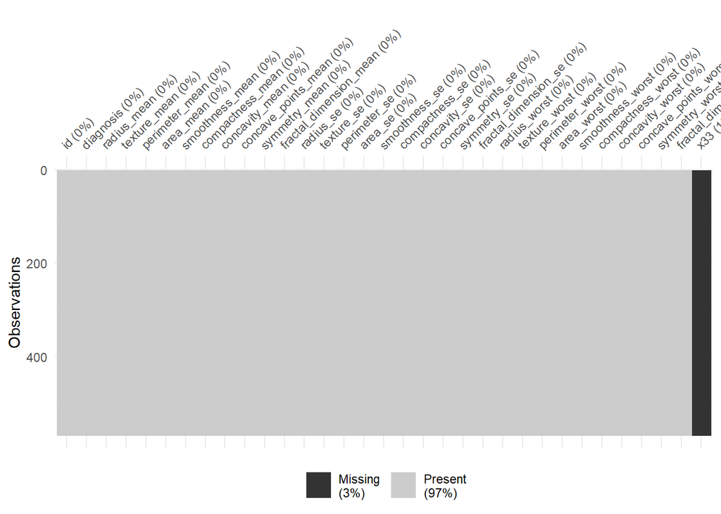

```r
data_cancer |> visdat::vis_miss()
```

A partir do gráfico de valores faltantes, nota-se que apenas uma coluna possui **NAs**, assim ela foi removida do conjunto de dados (variavel não apresentava nenhum valor e provalvelmente é resquício de um erro no upload dos dados por parte **UCI Machine Learning Repositor**)

```r
data_cancer = data_cancer|>
  dplyr::select(-'x33' )


data_cancer |> head()
```

```
# A tibble: 6 × 32
        id diagnosis radius_mean texture_mean perimeter_mean area_mean
     <dbl> <fct>           <dbl>        <dbl>          <dbl>     <dbl>
1   842302 M                18.0         10.4          123.      1001
2   842517 M                20.6         17.8          133.      1326
3 84300903 M                19.7         21.2          130       1203
4 84348301 M                11.4         20.4           77.6      386.
5 84358402 M                20.3         14.3          135.      1297
6   843786 M                12.4         15.7           82.6      477.
# ℹ 26 more variables: smoothness_mean <dbl>, compactness_mean <dbl>,
#   concavity_mean <dbl>, concave_points_mean <dbl>, symmetry_mean <dbl>,
#   fractal_dimension_mean <dbl>, radius_se <dbl>, texture_se <dbl>,
#   perimeter_se <dbl>, area_se <dbl>, smoothness_se <dbl>,
#   compactness_se <dbl>, concavity_se <dbl>, concave_points_se <dbl>,
#   symmetry_se <dbl>, fractal_dimension_se <dbl>, radius_worst <dbl>,
#   texture_worst <dbl>, perimeter_worst <dbl>, area_worst <dbl>, …
```

Um estudo de simulação, assim como a documentação dos dados indica que não há falta de informação ao se trabalhar apenas com as variáveis terminadas com **mean** como explicativas, assim, trabalhou-se apenas como aquelas terminadas em **mean** como variávies explicativas para a variável resposta **diagnosis**:

```r
data_cancer = data_cancer |>
  dplyr::select(id, diagnosis , dplyr::contains('_mean'))
```

O conjunto de dados possui 568 observações com 12 colunas restantes após a retirada das demais. Das 12, uma é o ID de cada observação e uma é a variável de interesse **diagnosis**.

Para o estudo, há a necessidade de verificação do balanceamento do conjunto de dados em relação ao diagnóstico do paciente (tumor maligno ou benigno).

Tal verificação foi feita em cima de análise gráfica, e via Coeficiente de Entropia de Shannon

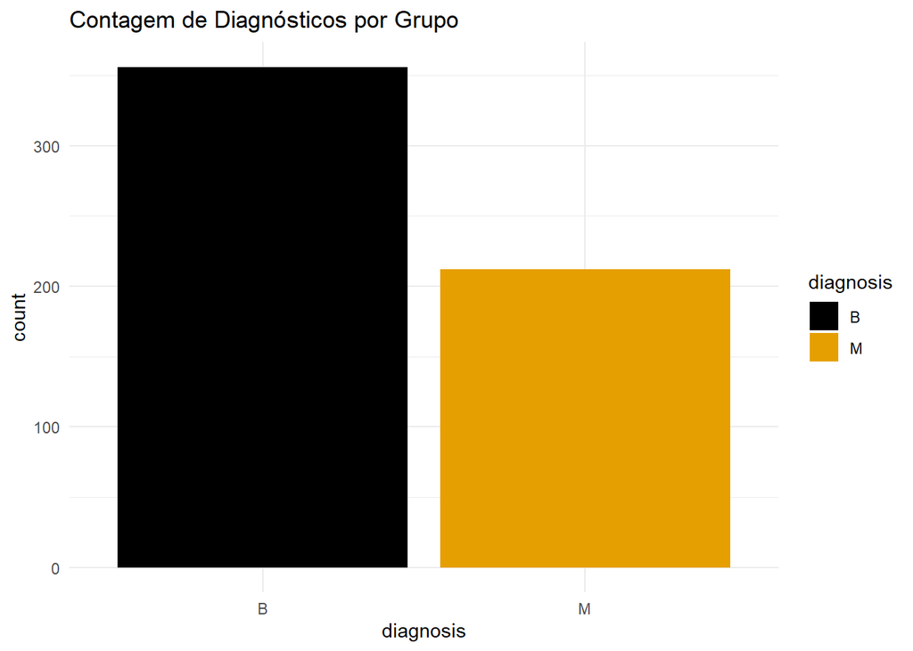

```r
prop_df = data_cancer |>
  dplyr::reframe(prop_B = mean(diagnosis == 'B'), prop_M = mean(diagnosis == 'M')) |>
  tidyr::pivot_longer(c(prop_B, prop_M))

data_cancer |>
  ggplot2::ggplot(ggplot2::aes(x = diagnosis, fill = diagnosis)) +
  ggplot2::geom_bar() +
  ggplot2::theme_minimal() +
  ggthemes::scale_fill_colorblind() +
  ggtitle("Contagem de Diagnósticos por Grupo")
```

Alem da visualização gráfica, foi utilizado o **Coeficiente de Entropia de Shannon**, que vai de 0 a 1, onde 0 indica dados totalmente desbalanceados (proporção $0\%$ e $100\%$) e 1 balanceamento completo (proporção $50\%$ e $50\%$)

```r
DescTools::Entropy(data_cancer$diagnosis |> table())
```

```
[1] 0.953127
```

O Coeficiente calculado foi de: $0.953127$

```r
set.seed(607) #Fixando semente para reprodução dos resultados
data_cancer_split = rsample::initial_split(data_cancer, prop = 0.80, strata = diagnosis)
data_cancer_train = rsample::training(data_cancer_split)
data_cancer_test = rsample::testing(data_cancer_split)
```

## 2.2 Análise e interpretação das variaveis

Buscando observar o comportamento de cada variável dividida por grupo de tratamento, construi-se o seguinte gráfico:

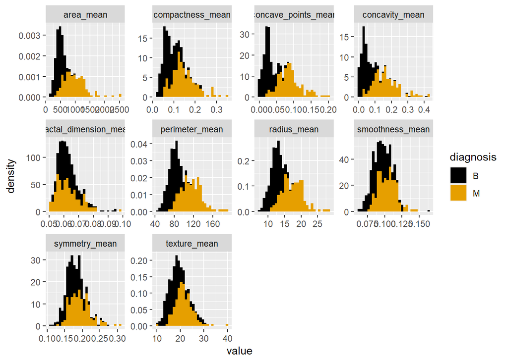

```r
library(tidyverse)

data_cancer_train |>
  dplyr::select(-id) |>
  pivot_longer(-diagnosis) |>
  ggplot(aes(x = value, fill = diagnosis)) +
  geom_histogram(aes(y = after_stat(density))) +
  facet_wrap(~name, scales = "free") +
  ggthemes::scale_fill_colorblind()
```

Observando os gráficos vemos que a variável area celular média divide bem os 2 grupos, assim como concavidade. Simetria e textura foram variáveis que não dividiram tão bem os grupos, onde eles se apresentam sobrepostos

Dada o número de variáveis do conjunto de dados, realizar uma análise individual seria demorada e tediosa, podendo mostrar pouco avanço na interpretação dos dados. Assim utilizou-se a técnica de redução de dimensionalidade para um melhor entendimento das relações entre as variáveis

## 2.3 Redução de dimensionalidade

Dados do mundo real, como sinais de fala, fotografias digitais ou varreduras de fMRI, geralmente têm alta dimensionalidade. Para lidar adequadamente com os dados do mundo real, dimensionalidade precisa ser reduzida. Redução de dimensionalidade é a transformação de dados de alta dimensão em uma representação significativa de dimensionalidade reduzida. Idealmente, a representação reduzida deve ter uma dimensionalidade que corresponde à dimensionalidade intrínseca dos dados (Van Der Maaten et al. 2009)

Dado a alta dimensionalidade dos dados trabalhados e buscando observar relações entre as variáveis analisadas, utilizou-se os métodos de **Ánalise de Componentes Principais e Análise Fatorial** para isso

### 2.3.1 Análise de Componentes Principais

Análise de Componentes Principais (PCA) constroi uma representação de baixa dimensão dos dados que descreve o máximo possível da variância dos dados.

A técnica se baseia no cálculo de autovalores e autovetores, buscando assim associção lineares entre as variáveis.

```r
pr_cancer = data_cancer_train |>
  dplyr::select(dplyr::contains('_mean')) |>
  princomp()
```

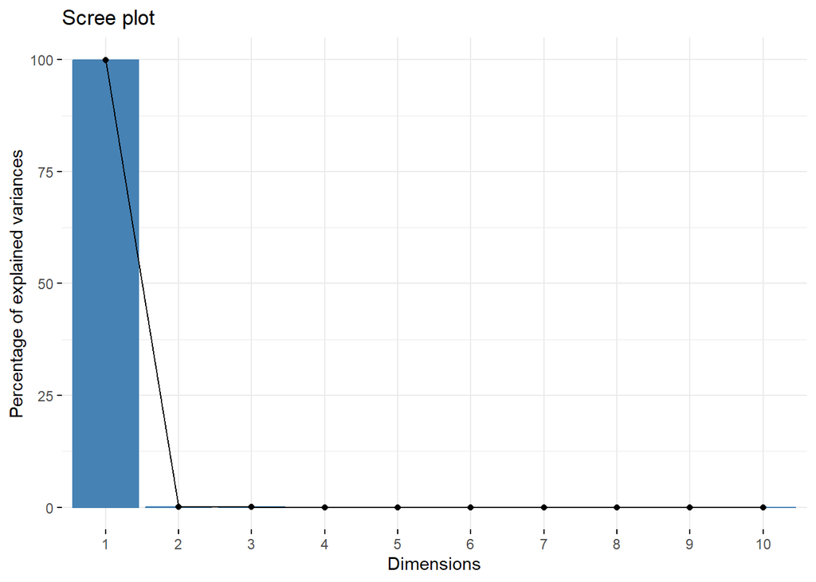

```r
pr_cancer |> factoextra::fviz_eig()
```

Observando o gráfico da variabilidade captada por cada componente, viu-se que a primeira dimensão captou grande parte dessa variabilidade e assim, trabalhou-se apenas com uma dimensão na análise dos dados via **PCA**

Buscando visualizar quanto cada variável contribui na primeira componente construiu-se o seguinte gráfico

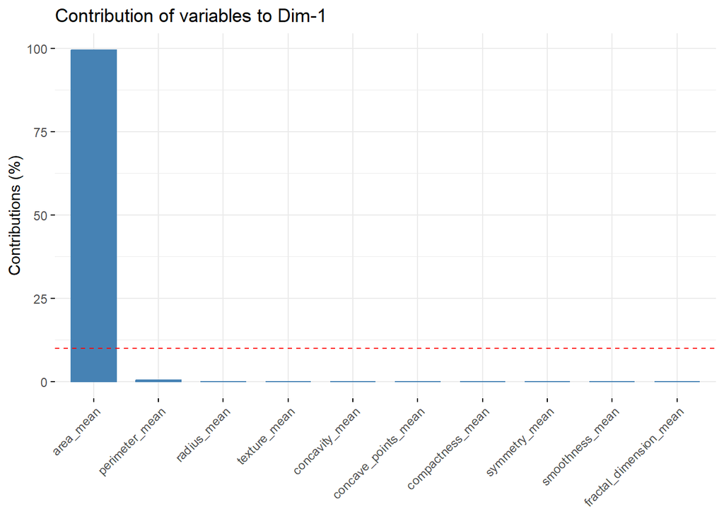

```r
pr_cancer |> factoextra::fviz_contrib(choice = "var", axes = c(1))
```

Viu-se que a variável **area_mean** foi predominante na primeira componente. As demais variáveis não foram captadas significativamente pela primeira componente, porém, ao se rankear elas, observou-se uma maior importância daquelas variáveis correspondentes ao questões de tamanho celulares, como: **area-mean, perimeter_mean, radius_mean**

Além disso, tais variáveis são altamente linearmente dependentes, onde tanto área como perímetro são função do raio.

Onde tem-se os seguintes valores de correlação:

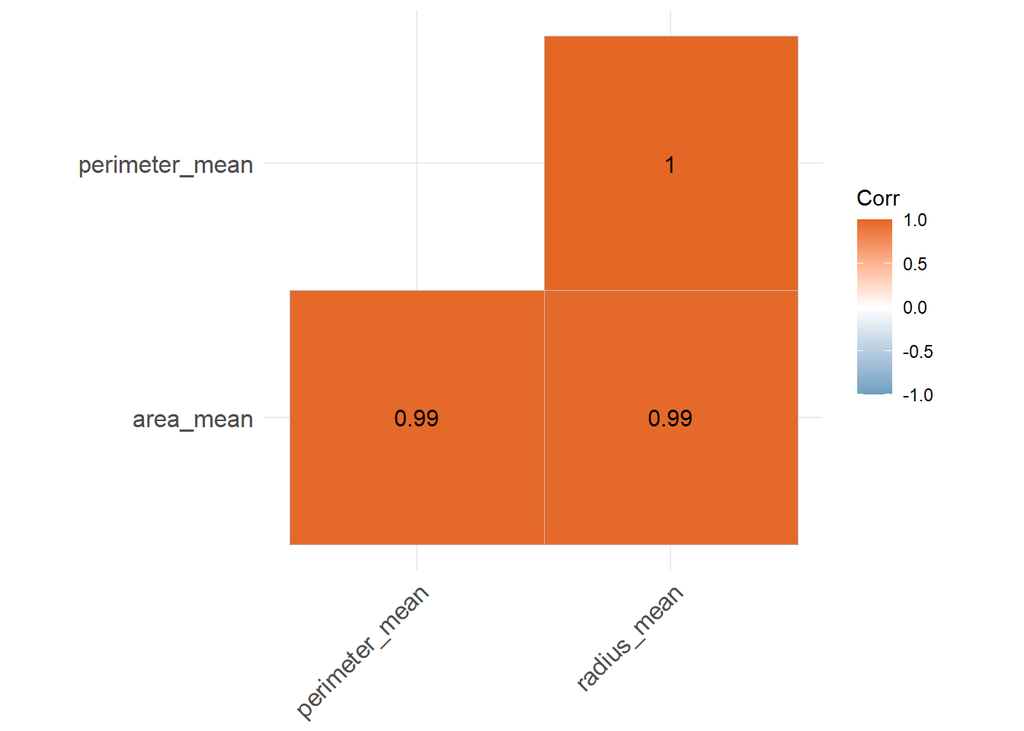

```r
data_cancer_train |>
  dplyr::select(area_mean, perimeter_mean, radius_mean) |>
  cor() |>
  ggcorrplot::ggcorrplot(hc.order = TRUE,
                         type = "lower",
                         lab = TRUE,
                         colors = c("#6D9EC1", "white", "#E46726"))
```

Assim, buscando eliminar multicolinearidade dos dados, eliminou-se as variáveis: **perimeter_mean, radius_mean**. A eliminação dessa variáveis não acarreta e perda de informações dado que área é função de raio e perímetro

Realizando novamente a redução de dimensionalidade, mas agora sem as variáveis **perimeter_mean, radius_mean**, tem-se:

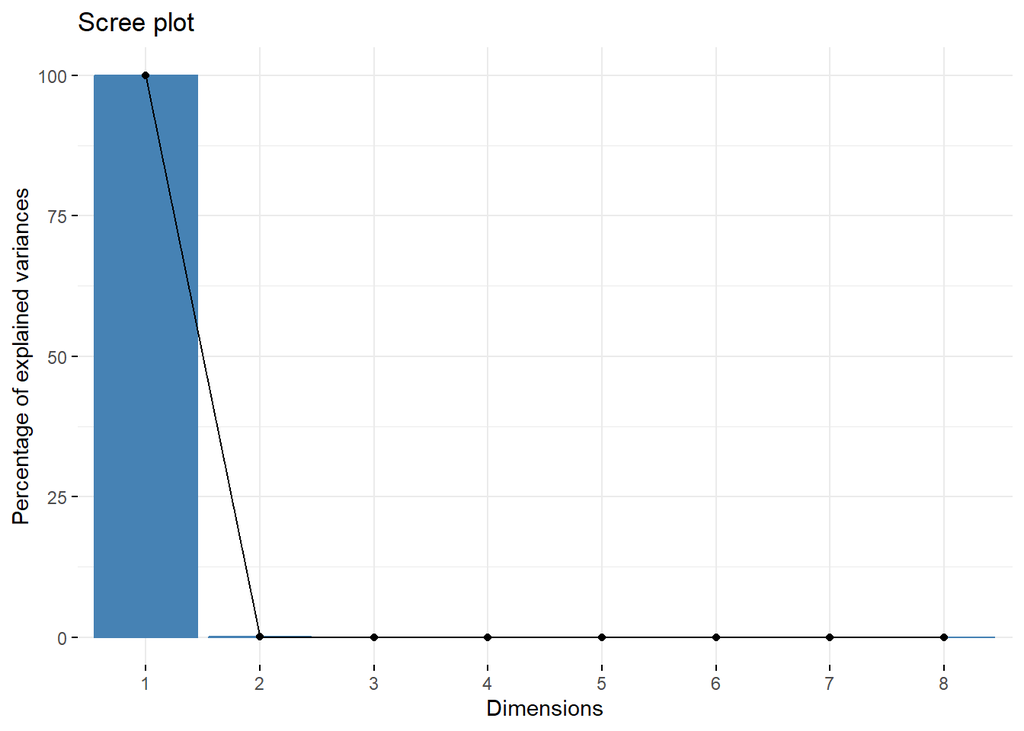

```r
pr_cancer = data_cancer_train |>
  dplyr::select(contains("_mean"),-perimeter_mean, -radius_mean) |>
  princomp()

pr_cancer |> factoextra::fviz_eig()
```

Observando o gráfico, viu-se que novamente a primeira componente captou cerca de $100\%$ da variabilidade dos dados

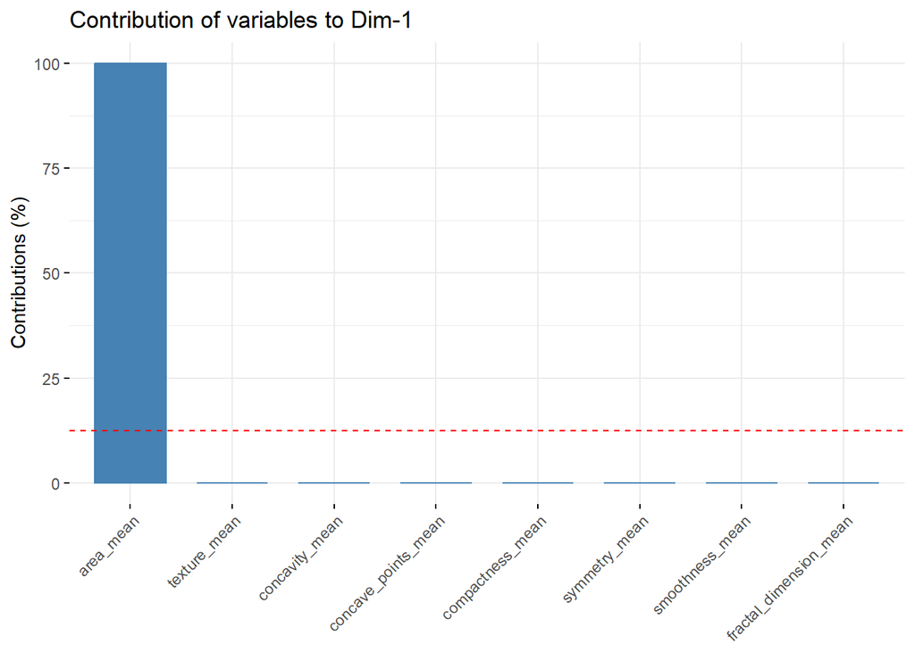

```r
pr_cancer |> factoextra::fviz_contrib(choice = "var", axes = c(1))
```

E novamente a variável **area_mean** foi aquele de maior importância na primeira componente

Plotando os valores de escore por grupo, construi-se o seguinte gráfico:

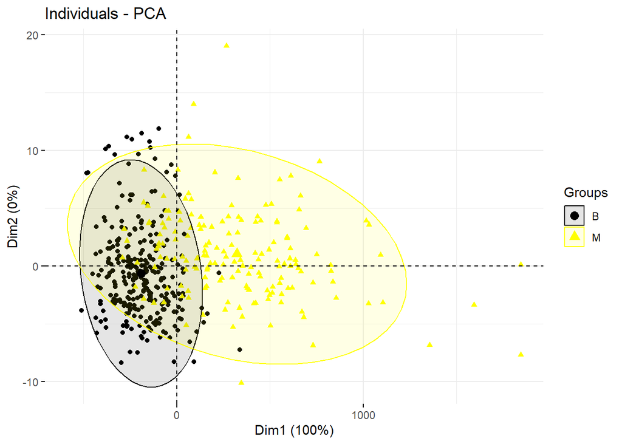

```r
factoextra::fviz_pca_ind(pr_cancer,
             label = "none", # hide individual labels
             habillage = data_cancer_train$diagnosis, # color by groups
             palette = c('black', 'yellow'),
             addEllipses = TRUE # Concentration ellipses
             )
```

É possivel notar que o grupo de tumor benigno se possui uma variabilidade menor que o grupo de tumor maligno. Além disso, o grupo de tumor benigno se concentra em valores negativos e perto de 0 no eixo X, enquanto o grupo de tumor maligno se concentra em valores positivos no eixo X.

Segundo Karhunen and Joutsensalo (1995), quando a primeira componente captura cerca de $100\%$ da variabilidade dos dados, isso pode indicar que todas as variáveis podem ser escritas como uma transformação linear de uma delas, isso é, em algebra linear, todas as variáveis são linearmente dependentes e dado que cada componente é uma base vetorial, necessita-se apenas de uma base para escrever todas os vetores desse sistema

Assim, buscando contornar tal problema, foi utilizado o método de engenharia de características.

Engenharia de características (feature engineering) é o processo de selecionar, transformar e criar atributos (características) relevantes a partir dos dados brutos para melhorar o desempenho e eficácia de modelos (Nargesian et al. 2017). O grupamento de características pode ser feito de 2 formas:

- Utilizando conhecimento prévio na área de estudo, e portanto agrupando variáveisem um que agrupamento faça sentido
- Utilizando redução de dimensionalidade, é possível usar técnicas como PCA ou FA para reduzir a complexidade dos dados, identificando combinações lineares de atributos que expliquem a maior parte da variabilidade.

Além disso, é possivel combinar as duas abordagens visando melhores transformações.

Utilizou-se a abordagem de redução de dimensionalidade via **FA** para o agrupamento de características

### 2.3.2 Análise Fatorial

Análise fatorial é uma técnica estatística que busca identificar padrões ou estruturas subjacentes em um conjunto de variáveis observadas, reduzindo sua dimensionalidade e representando-as em termos de fatores latentes que explicam sua covariância.

O modelo fatorial pode utilizar diversos métodos de factorização, as mais conhecidas e aquelas que foram utilizadas no trabalho são:

- **Resíduos Mínimos**
- **Máxima Verossimilhança**
- **Fatores Principais**

Além disso, foi aplicado a rotação **varimax** nos 3 modelos, onde tal método auxiliou na interpretação de varivaies dentre de cada fator

```r
fa_rm_cancer = data_cancer_train |>
                dplyr::select(dplyr::contains('_mean'), -'perimeter_mean', -'radius_mean') |>
  psych::fa(nfactors = 3, rotate = 'varimax', fm = 'minres')


fa_ml_cancer = data_cancer_train |>
                dplyr::select(dplyr::contains('_mean'), -'perimeter_mean', -'radius_mean') |>
  psych::fa(nfactors = 3, rotate = 'varimax', fm = 'ml')

fa_pcomp_cancer = data_cancer_train |>
                dplyr::select(dplyr::contains('_mean'), -'perimeter_mean', -'radius_mean') |>
  psych::fa(nfactors = 3, rotate = 'varimax', fm = 'pa')
```

Após o calculo dos fatores para cada modelo, construi-se os seguintes gráficos

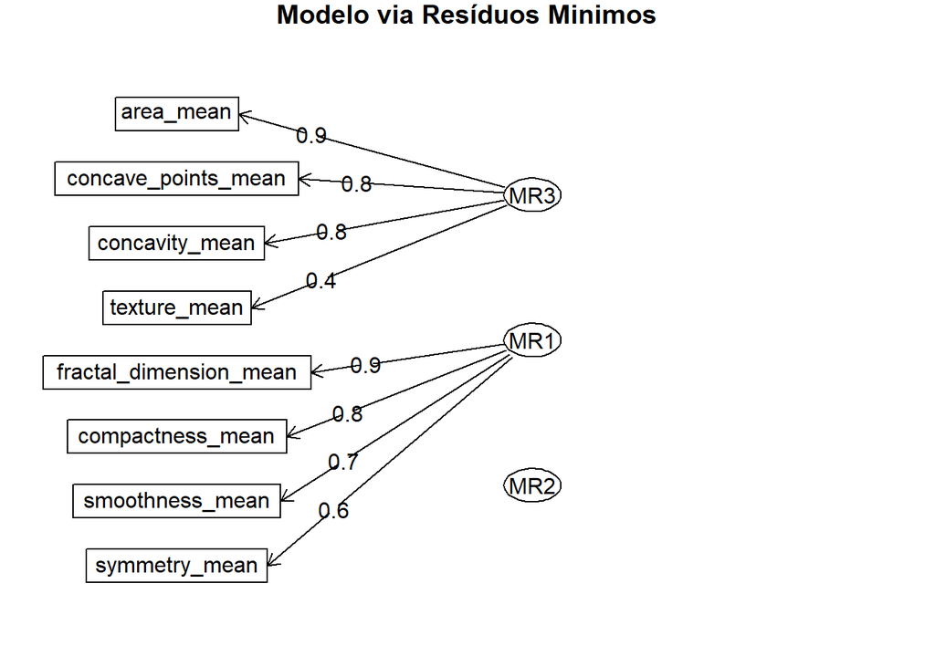

```r
fa_rm_cancer |> psych::fa.diagram(main = 'Modelo via Resíduos Minimos')
```

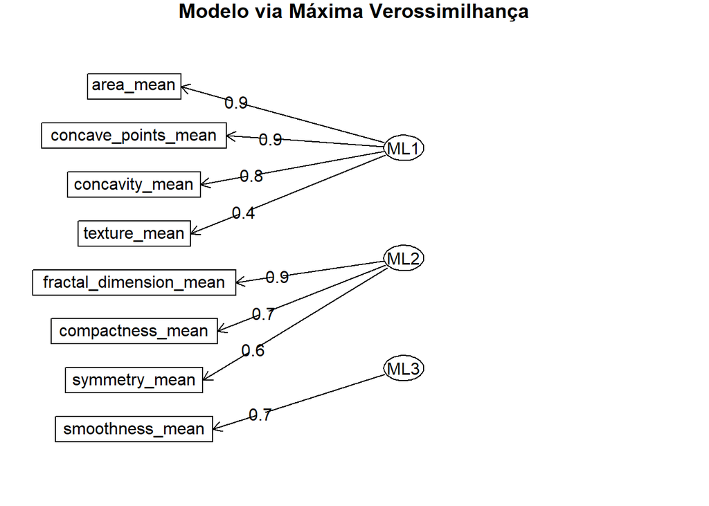

```r
fa_ml_cancer |> psych::fa.diagram(main = 'Modelo via Máxima Verossimilhança')
```

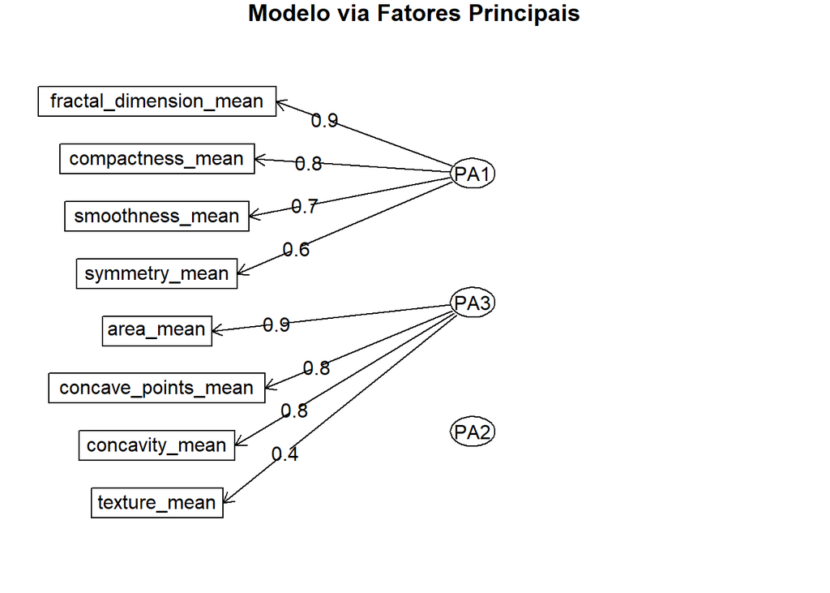

```r
fa_pcomp_cancer |> psych::fa.diagram(main = 'Modelo via Fatores Principais')
```

É possível ver que a utilização de 2 fatores foi suficiente em 2 dos 3 modelos construidos (Resíduos Mínimos e Fatores Principais). O modelo de via Máxima Verossimilhança utilizou um terceiro fator para a variável **smoothness_mean** ser separada das demais.

Assim, observando os fatores os interpretando, tem-se que:

- Fator 1: Esse fator pode ser interpretado como um indicador de características relacionadas à forma e ao tamanho das células. As variáveis com maiores loadings, como área celular, pontos concavos, concavidade média e textura celular, sugerem que esse fator está relacionado à irregularidade e complexidade das células, possivelmente refletindo a presença de células com formas anormais ou características específicas associadas ao câncer de mama.
- Fator 2: Esse fator pode ser interpretado como um indicador de características relacionadas à estrutura e textura das células. As variáveis com maiores loadings, como dimensão fractal, suavidade celular, compacidade celular e simetria celular, sugerem que esse fator está relacionado à organização estrutural das células, possivelmente refletindo a uniformidade ou padrões na estrutura celular. Pode indicar diferenças nas propriedades estruturais das células cancerígenas em comparação com células saudáveis.

A partir dessas interpretções descritas, foi possivel construir novas variáveis, as chamadas **features**.

## 2.4 Engenharia de Características

Utilizando os modelos fatoriais construídos no tópico anterior, foram construidas duas novas variaveis, onde essas foram utilizadas no tópico de modelagem:

**TODAS AS VARIÁVEIS FORAM PADRONIZADAS ANTES DE SEREM UTILIZADAS NAS FUNÇÕES**

- **anomaly_feature** = Característica de anomalia celular. É dada pela seguinte função

**anomaly_features: media(area_mean, concave_points_mean, concavity_mean, texture_mean)**

- **structure_feature**: Característica de estrutura celular. É dada pela seguinte função:

**structure_feature = media(compactness_mean, fractal_dimension_mean, smoothness_mean, symmetry_mean)**

```r
library(tidymodels)

variables_to_remove = data_cancer |>
  dplyr::select(contains("_mean")) |>
  names()

cancer_recipes = recipes::recipe(diagnosis ~ .,
                                data = data_cancer_train) |>
      recipes::update_role(id, new_role = "id") |>
      step_normalize(all_predictors()) |>
      step_mutate(anomaly_feature = (area_mean + concave_points_mean + concavity_mean + texture_mean)/4,
                  structure_feature = (compactness_mean + fractal_dimension_mean + smoothness_mean + symmetry_mean)/4) |>
  update_role(all_of(variables_to_remove), new_role = "ignore")

data_cancer_features = cancer_recipes |>
  prep() |>
  bake(new_data = NULL) |>
  dplyr::select(-contains("_mean"))
```

Arafa, Ahmed, Marwa Radad, Mohammed Badawy, and Nawal El-Fishawy. 2021. “Regularized Logistic Regression Model for Cancer Classification.” In *2021 38th National Radio Science Conference (NRSC)*, 1:251–61. IEEE.

Karhunen, Juha, and Jyrki Joutsensalo. 1995. “Generalizations of Principal Component Analysis, Optimization Problems, and Neural Networks.” *Neural Networks* 8 (4): 549–62.

Nargesian, Fatemeh, Horst Samulowitz, Udayan Khurana, Elias B Khalil, and Deepak S Turaga. 2017. “Learning Feature Engineering for Classification.” In *Ijcai*, 17:2529–35.

Van Der Maaten, Laurens, Eric O Postma, H Jaap van den Herik, et al. 2009. “Dimensionality Reduction: A Comparative Review.” *Journal of Machine Learning Research* 10 (66-71): 13.